# Experiment 1 Analysis

Bonan Zhao

10/16/2021

```r
# Packages
library(tidyverse)

# Data sources
load('./exp_1/data/behavioral.Rdata')
load('./exp_1/data/model_data.Rdata')
load('./exp_1/data/grid_preds_01.Rdata')
df.trials=read.csv('../behavioral_data/exp1_trials.csv')
```

# Generalization consistency

We use Cronbach’s alpha to measure inter-person consistency. Specifically, the Kuder-Richardson Formula 21 (KR-21), a simplified version of Cronbach’s alpha known to be more conservative. The resulting consistency measure ranges between 0 - indicating uniform spread across all selections - and 1 - indicating perfect agreement between participants. (See Experiment 1 Results section, pp.9-10.)

```r
# Function to calculate Cronbach's alpha
KR21<-function(x) {
  # Implements Equation 13 on p.9
  k=sum(x)
  n=length(x)
  p=1/n
  rho<-(k/(k-1))*(1-(k*p*(1-p)/var(x)))
  # Safety cap
  rho<-min(rho, 1)
  rho<-max(rho, 0)
  return(rho)
}

# Prep return data frame
consistency<-df.sels %>%
  select(learningTaskId, sequence, trial) %>%
  distinct()

# Measure inter-person generalization consistency
for (i in 1:nrow(consistency)) {
  counts<-df.sels %>%
    filter(learningTaskId==consistency[i,'learningTaskId'],
           sequence==consistency[i,'sequence'],
           trial==consistency[i,'trial']) %>%
    pull(n)
  consistency[i,'kr21']<-KR21(counts)
  consistency[i,'cond']<-paste0('L',substr(consistency[i,'learningTaskId'],7,7))
}
```

## Plots and statistical tests

Task-wise consistency measure demonstrates that participants made systematic one-shot causal generalizations.

```r
tests = df.trials %>%
  select(ix, condition=learningTaskId, order, trial, result=selection) %>%
  mutate(
    condition=as.factor(condition),
    order=as.factor(order),
    trial=as.factor(trial),
    result=as.factor(result))

fisher.test(table(tests$trial, tests$result), simulate.p.value=TRUE)
```

```
##
##  Fisher's Exact Test for Count Data with simulated p-value (based on
##  2000 replicates)
##
## data:  table(tests$trial, tests$result)
## p-value = 0.0004998
## alternative hypothesis: two.sided
```

Generalizations were more consistent overall under near-first transfer, compared with far-first transfer (**Fig. 4A**: Cronbach’s alpha per learning condition)

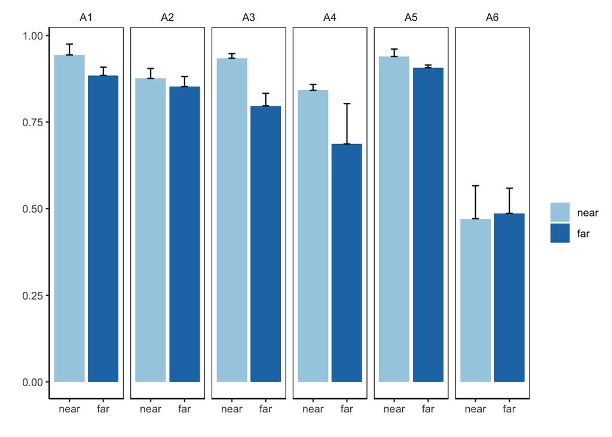

```r
# Prep data
agg_con<-consistency %>%
  filter(sequence!='combined') %>%
  mutate(sequence=ifelse(sequence=='default', 'near', 'far'),
         condition=paste0('A',substr(learningTaskId,7,7))) %>%
  mutate(sequence=factor(sequence, levels=c('near','far'))) %>%
  select(condition, sequence, trial, kr21) %>%
  group_by(condition, sequence) %>%
  summarise(mean=mean(kr21), sd=sd(kr21))

ppt<-df.sels %>%
  filter(sequence!='combined') %>%
  group_by(learningTaskId, sequence) %>%
  summarise(n=sum(n)/15) %>%
  mutate(sequence=ifelse(sequence=='default', 'near', 'far'),
         condition=paste0('A',substr(learningTaskId,7,7)))  %>%
  mutate(sequence=factor(sequence, levels=c('near','far'))) %>%
  ungroup() %>%
  select(condition, sequence, n)

agg_con %>%
  left_join(ppt, by=c('condition', 'sequence')) %>%
  mutate(se=sd/sqrt(n)) %>%
  ggplot(aes(x=sequence, y=mean, fill=sequence)) +
  geom_bar(stat='identity') +
  geom_errorbar(aes(ymin=mean, ymax=mean+se), width=0.2) +
  facet_grid(~condition) +
  theme_classic() +
  scale_fill_brewer(palette='Paired') +
  labs(x='', fill='', y='') +
  theme(strip.background = element_rect(colour=NA, fill=NA),
        panel.border = element_rect(fill = NA, color = "black"))
```

```r
near_kr<-consistency %>% filter(sequence=='default') %>% pull(kr21)
far_kr<-consistency %>% filter(sequence=='reverse') %>% pull(kr21)
t.test(near_kr, far_kr, paired = T)
```

```
##
##  Paired t-test
##
## data:  near_kr and far_kr
## t = 3.5359, df = 89, p-value = 0.0006477
## alternative hypothesis: true difference in means is not equal to 0
## 95 percent confidence interval:
##  0.02861982 0.10204981
## sample estimates:
## mean of the differences
##              0.06533482
```

Participants generalized less consistently when the learning task involved new colors or new shapes (**Fig. 4B**: Cronbach’s alpha per learning data types). For learning scenes A1, A3, and A5, where effect states *match* agents’ features, overall consistency was high. Learning scenes A2, A4, and A6, where effects involved brand *new* values, consistency was lower, differing significantly from the *match* group.

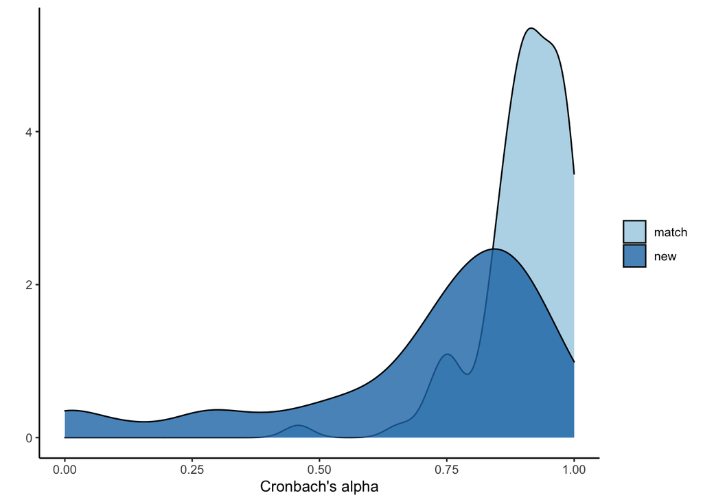

```r
# Pull out data
c.data<-consistency %>% filter(sequence!='combined')

# Plot match (A1, A3, A5) vs. new (A2, A4, A6), p.10
c.data %>%
  mutate(effect=ifelse(learningTaskId %in% c('learn01', 'learn03', 'learn05'), 'match', 'new')) %>%
  ggplot(aes(x=kr21, fill=effect)) +
  geom_density(alpha=0.8) +
  labs(x="Cronbach's alpha", y='', fill='') +
  scale_fill_brewer(palette='Paired') +
  theme_classic()
```

```r
exi_kr<-c.data %>% filter(learningTaskId %in% c('learn01', 'learn03', 'learn05')) %>% pull(kr21)
new_kr<-c.data %>% filter(learningTaskId %in% c('learn02', 'learn04', 'learn06')) %>% pull(kr21)

t.test(exi_kr, new_kr, paired = T)
```

```
##
##  Paired t-test
##
## data:  exi_kr and new_kr
## t = 6.961, df = 89, p-value = 5.543e-10
## alternative hypothesis: true difference in means is not equal to 0
## 95 percent confidence interval:
##  0.1418696 0.2552154
## sample estimates:
## mean of the differences
##               0.1985425
```

Color and shape changes were generalized to different extents despite these features appearing in symmetric and counterbalanced contexts in the task (**Fig. 4C**: Cronbach’s alpha per feature change). Shape changes (A1, A2) induced more homogeneous predictions, compared to color changes (A3, A4).

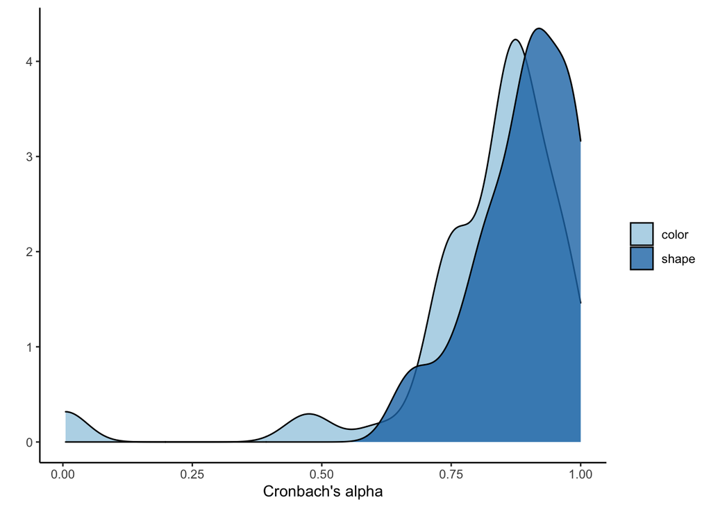

```r
c.data %>%
  filter(!(learningTaskId %in% c('learn05','learn06'))) %>%
  mutate(feat=ifelse(learningTaskId %in% c('learn01', 'learn02'), 'shape', 'color')) %>%
  ggplot(aes(x=kr21, fill=feat)) +
  geom_density(alpha=0.8) +
  labs(x="Cronbach's alpha", y='', fill='') +
  scale_fill_brewer(palette='Paired') +
  theme_classic()
```

```r
sha_kr<-c.data %>% filter(learningTaskId %in% c('learn01', 'learn02')) %>% pull(kr21)
col_kr<-c.data %>% filter(learningTaskId %in% c('learn03', 'learn04')) %>% pull(kr21)

t.test(sha_kr,col_kr,paired = T)
```

```
##
##  Paired t-test
##
## data:  sha_kr and col_kr
## t = 2.8843, df = 59, p-value = 0.005469
## alternative hypothesis: true difference in means is not equal to 0
## 95 percent confidence interval:
##  0.02278001 0.12599443
## sample estimates:
## mean of the differences
##              0.07438722
```

# Models

See `./exp_1` folder for model implementations, optimized parameters, and BIC values.

Plot behavioral data:

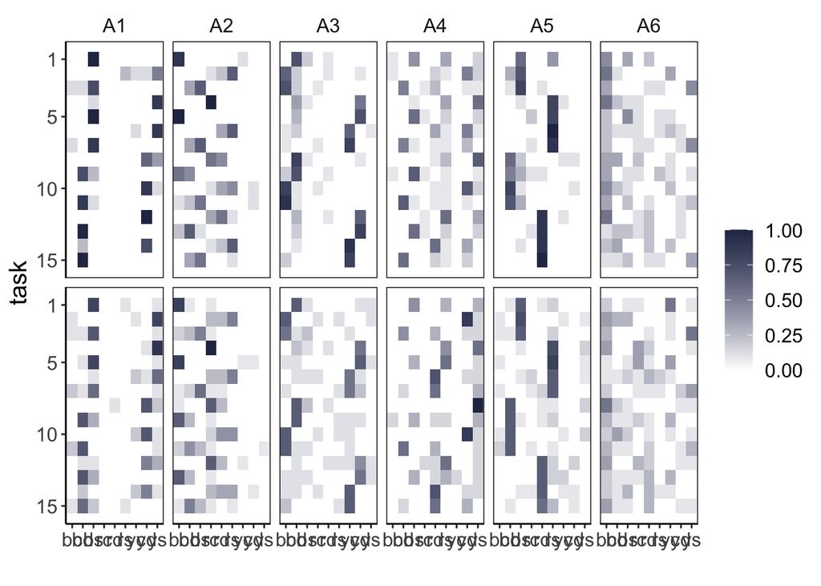

```r
textsize = 15

# Plot behavioral data
ppt_near<-df.sels %>%
  filter(sequence=='default') %>%
  mutate(condition=paste0('A',substr(learningTaskId,7,7)),
         object=selection, prob=freq, mname='ppt_near',
         sequence=ifelse(sequence=='default', 'near', 'far')) %>%
  select(condition, trial, object, prob, mname, sequence)

ppt_far<-df.sels %>%
  filter(sequence=='reverse') %>%
  mutate(condition=paste0('A',substr(learningTaskId,7,7)),
         object=selection, prob=freq, mname='ppt_far',
         sequence=ifelse(sequence=='default', 'near', 'far')) %>%
  select(condition, trial, object, prob, mname, sequence)

beh<-rbind(ppt_near, ppt_far) %>%
  mutate(sequence=factor(sequence, levels=c('near', 'far'))) %>%
  ggplot(aes(x=object, y=trial, fill=prob)) +
  geom_tile() +
  labs(x='', y='task', fill='') + #title='Behavioral data'
  scale_y_continuous(trans="reverse", breaks=c(1,5,10,15)) +  # breaks=seq(15)
  scale_fill_gradient(low='white', high='#293352') +
  theme_classic() +
  theme(strip.background = element_rect(colour=NA, fill=NA),
        panel.border = element_rect(fill = NA, color = "black"),
        text = element_text(size=textsize),
        strip.text.y = element_blank()
        ) +
  facet_grid(sequence~condition)

beh
```

Plot best-fitted LoCaLaPro model:

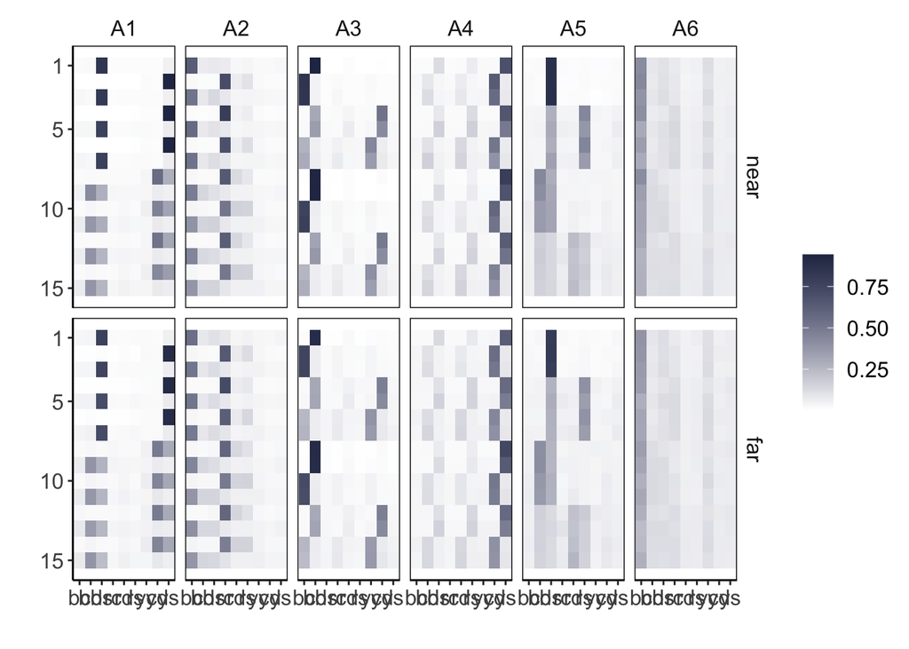

```r
proc_near<-exp1.localapro %>%
  filter(sequence=='near') %>%
  mutate(condition=paste0('A',substr(learningTaskId,7,7)),
         mname='process_near') %>%
  select(condition, trial, object, prob=prob_s, mname, sequence)

proc_far<-exp1.localapro %>%
  filter(sequence=='far') %>%
  mutate(condition=paste0('A',substr(learningTaskId,7,7)), mname='process_far') %>%
  select(condition, trial, object, prob=prob_s, mname, sequence)

fit<-rbind(proc_near, proc_far) %>%
  mutate(sequence=factor(sequence, levels=c('near', 'far'))) %>%
  ggplot(aes(x=object, y=trial, fill=prob)) +
  geom_tile() +
  labs(x='', y='', fill='') + # title='Process model: fitted'
  scale_y_continuous(trans="reverse", breaks=c(1,5,10,15)) +
  scale_fill_gradient(low='white', high='#293352') +
  theme_classic() +
  theme(strip.background = element_rect(colour=NA, fill=NA),
        panel.border = element_rect(fill = NA, color = "black"),
        text = element_text(size=textsize)
        ) +
  facet_grid(sequence~condition)
fit
```

Plot model with small alpha values:

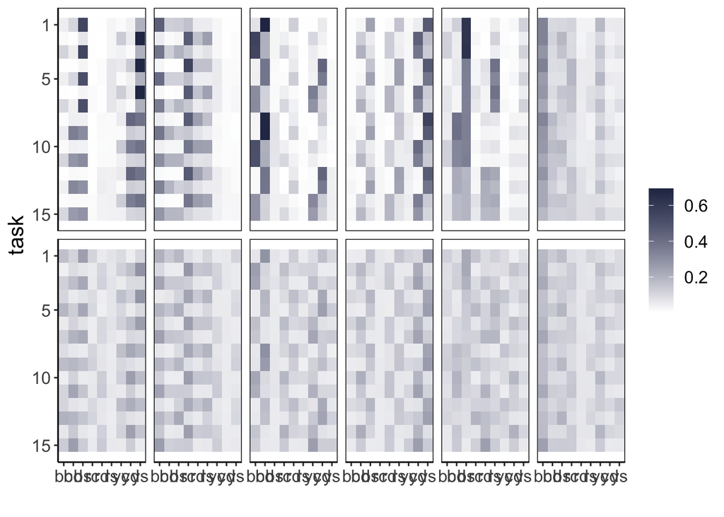

```r
order_preds<-grid_preds_01[[1]]
small<-order_preds %>%
  mutate(condition=paste0('A',substr(learningTaskId,7,7)), prob=sim/10000,
         sequence=factor(sequence, levels=c('near', 'far'))) %>%
  ggplot(aes(x=object, y=trial, fill=prob)) +
  geom_tile() +
  labs(x='', y='task', fill='') + #  title='Process model: alpha = 0.01'
  scale_y_continuous(trans="reverse", breaks=c(1,5,10,15)) +
  scale_fill_gradient(low='white', high='#293352') +
  theme_classic() +
  theme(strip.background = element_rect(colour=NA, fill=NA),
        panel.border = element_rect(fill = NA, color = "black"),
        text = element_text(size=textsize),
        strip.text.x = element_blank(),
        strip.text.y = element_blank()
        ) +
  facet_grid(sequence~condition)
small
```

Plot model with large alpha values:

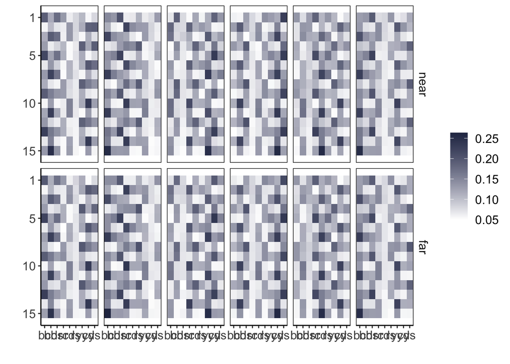

```r
rand_preds<-grid_preds_01[[15]]
large<-rand_preds %>%
  mutate(condition=paste0('A',substr(learningTaskId,7,7)), prob=sim/10000,
         sequence=factor(sequence, levels=c('near', 'far'))) %>%
  ggplot(aes(x=object, y=trial, fill=prob)) +
  geom_tile() +
  labs(x='', y='', fill='') + #title='Process model: alpha = 8'
  scale_y_continuous(trans="reverse", breaks=c(1,5,10,15)) +
  scale_fill_gradient(low='white', high='#293352') +
  theme_classic() +
  theme(strip.background = element_rect(colour=NA, fill=NA),
        panel.border = element_rect(fill = NA, color = "black"),
        text = element_text(size=textsize),
        strip.text.x = element_blank()) +
  facet_grid(sequence~condition)
large
```